# Coursera - Practical ML. Prediction Assignment Writeup

IuriiR23

6/1/2019

# 1. Uploading, reading & cleaning the data

```r
library(foreign)
training <- read.csv2("D:/R/pml-training.csv", sep = ",")
testing <- read.csv2("D:/R/pml-testing.csv", sep = ",")
```

```r
table(training$classe)
```

```
##
##    A    B    C    D    E
## 5580 3797 3422 3216 3607
```

### Checking a type of the data

```r
lapply(training0, class)
```

### Factros to numeric data, missings to NAs

```r
factorsNumeric <- function(training) modifyList(training, lapply(training[, sapply(training, is.factor)],asNumeric))
asNumeric <- function(x) as.numeric(as.character(x))
training0 <- factorsNumeric(training)
```

### Removing variables that are mostly NAs

```r
AllNA <- sapply(training0, function(x) mean(is.na(x))) > 0.95
training00 <- training0[, AllNA==FALSE]
dim(training00)
```

```
## [1] 19622    56
```

### Excluding other non-relevant variables

```r
training000 <- training00[,-c(1:4)]
dim(training000)
```

```
## [1] 19622    52
```

### Adding outcome variable

```r
training1 <- data.frame(training000, training$classe)
training1$classe <- training1$training.classe
training1 <- training1[,-c(53)]
dim(training1)
```

```
## [1] 19622    53
```

# 2. Splitting dataset

The initial training dataset is splitted into a training set (85% of the data) and a validation set (with the remaining 15%). This ratio of partitioning is selected because the initial training dataset is extremely large comparing to the testing set, so the size of a validation set might be less.

```r
library(caret)
set.seed(1011)
inTrain <- createDataPartition(training1$classe, p = 0.85, list = F)
trset <- training1[inTrain,]
teset <- training1[-inTrain,]
```

# 3. Exploratory analysis and feature selection with PCA

Performing PCA to explore the opportunity for reduction of dimensionality and feature selection.

```r
library(factoextra)
```

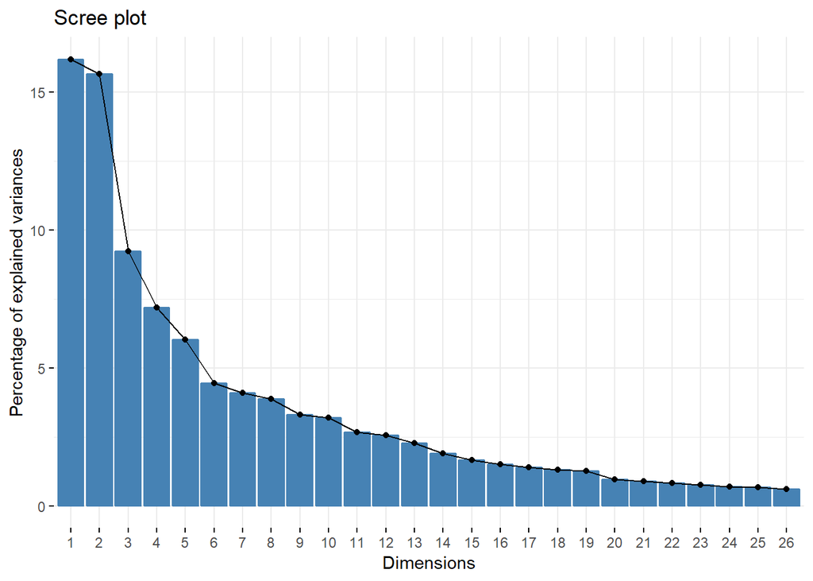

```r
set.seed(10122)
pc <- prcomp(trset[,-c(53)], scale.=T)
fviz_screeplot(pc, ncp=26)
```

26 components expain 95% of variance. PCA significantly reduced dimentionality of data. Plot cumulative variables’ contribution to top 26 components.

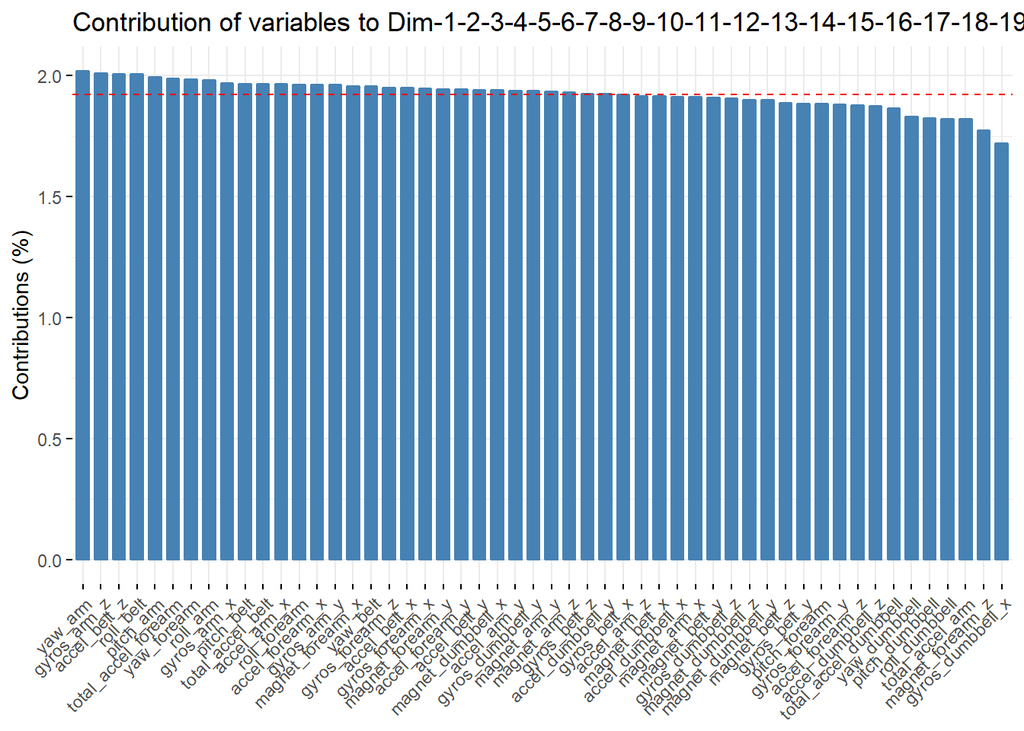

```r
fviz_contrib(pc, choice = "var", axes = 1:26)
```

Get variables contributions to top 26 components as data.frame. Components as observations

```r
# Get variables contributions to top 26 components as data.frame. Components as observations
res.var <- get_pca_var(pc)
con <- as.data.frame(t(res.var$contrib[,c(1:26)]))

# Get explained variance for top 26 components.
var <- (((pc$sdev)^2)/sum((pc$sdev)^2))[1:26]

## Weighting contributions of variables by importance of components
conX <- con*var
conX <- rbind(conX, colSums(conX))
## Selecting the total contribution 'observation'
conT <- conX[c(27),]
rownames(conT) <- c("Total")
conT2 <- as.data.frame(t(conT))
conF <- subset(conT2, Total > (mean(conT2$Total)))
dim(conF)
```

```
## [1] 30  1
```

```r
## The list of 30 variables which contributed most into top 26 components.
list <- names(as.data.frame(t(conF)))

## Final training data set
trainF <- trset[list]
trainF$classe <- trset$classe
dim(trainF)
```

```
## [1] 16680    31
```

# 4. Prediction modeling

## 4.1. KNN model

```r
set.seed(102)
modknn <- train(classe ~., method="knn", data = trainF)
predknn <- predict(modknn, newdata=teset)
confusionMatrix(predknn, teset$classe)
```

```
## Confusion Matrix and Statistics
##
##           Reference
## Prediction   A   B   C   D   E
##          A 789  29   9  10  17
##          B   7 502  25   6  24
##          C  12  18 456  37  14
##          D  26  13  16 425  26
##          E   3   7   7   4 460
##
## Overall Statistics
##
##                Accuracy : 0.8946
##                  95% CI : (0.883, 0.9055)
##     No Information Rate : 0.2845
##     P-Value [Acc > NIR] : < 2.2e-16
##
##                   Kappa : 0.8667
##
##  Mcnemar's Test P-Value : 3.376e-11
##
## Statistics by Class:
##
##                      Class: A Class: B Class: C Class: D Class: E
## Sensitivity            0.9427   0.8822   0.8889   0.8817   0.8503
## Specificity            0.9691   0.9739   0.9667   0.9671   0.9913
## Pos Pred Value         0.9239   0.8901   0.8492   0.8399   0.9563
## Neg Pred Value         0.9770   0.9718   0.9763   0.9766   0.9671
## Prevalence             0.2845   0.1934   0.1744   0.1638   0.1839
## Detection Rate         0.2682   0.1706   0.1550   0.1445   0.1564
## Detection Prevalence   0.2903   0.1917   0.1825   0.1720   0.1635
## Balanced Accuracy      0.9559   0.9281   0.9278   0.9244   0.9208
```

```r
set.seed(103)
modknn1 <- train(classe ~., method="knn", data = trainF, trControl=trainControl(method="cv",number=20))
predknn1 <- predict(modknn1,newdata=teset)
confusionMatrix(predknn1, teset$classe)
```

```
## Confusion Matrix and Statistics
##
##           Reference
## Prediction   A   B   C   D   E
##          A 787  33   9   8  16
##          B   7 498  24   4  25
##          C  12  19 457  39  16
##          D  28  13  17 428  26
##          E   3   6   6   3 458
##
## Overall Statistics
##
##                Accuracy : 0.8933
##                  95% CI : (0.8815, 0.9042)
##     No Information Rate : 0.2845
##     P-Value [Acc > NIR] : < 2.2e-16
##
##                   Kappa : 0.865
##
##  Mcnemar's Test P-Value : 3.704e-14
##
## Statistics by Class:
##
##                      Class: A Class: B Class: C Class: D Class: E
## Sensitivity            0.9403   0.8752   0.8908   0.8880   0.8466
## Specificity            0.9686   0.9747   0.9646   0.9659   0.9925
## Pos Pred Value         0.9226   0.8925   0.8416   0.8359   0.9622
## Neg Pred Value         0.9761   0.9702   0.9767   0.9778   0.9663
## Prevalence             0.2845   0.1934   0.1744   0.1638   0.1839
## Detection Rate         0.2675   0.1693   0.1553   0.1455   0.1557
## Detection Prevalence   0.2899   0.1897   0.1846   0.1740   0.1618
## Balanced Accuracy      0.9545   0.9250   0.9277   0.9269   0.9195
```

Resampling does not add predictive power and reduce out of sample error for KNN model. The accuracy of the best KNN model is **0.8946**.

## 4.2. Decision Trees

```r
modt <- train(classe ~., method="rpart", data = trainF)
predt <- predict(modt,newdata=teset)
confusionMatrix(predt, teset$classe)
```

```
## Confusion Matrix and Statistics
##
##           Reference
## Prediction   A   B   C   D   E
##          A 741 400 233 307 101
##          B   0   0   0   0   0
##          C  94 169 280 175 171
##          D   0   0   0   0   0
##          E   2   0   0   0 269
##
## Overall Statistics
##
##                Accuracy : 0.4385
##                  95% CI : (0.4204, 0.4566)
##     No Information Rate : 0.2845
##     P-Value [Acc > NIR] : < 2.2e-16
##
##                   Kappa : 0.2592
##
##  Mcnemar's Test P-Value : NA
##
## Statistics by Class:
##
##                      Class: A Class: B Class: C Class: D Class: E
## Sensitivity            0.8853   0.0000  0.54581   0.0000  0.49723
## Specificity            0.5055   1.0000  0.74928   1.0000  0.99917
## Pos Pred Value         0.4158      NaN  0.31496      NaN  0.99262
## Neg Pred Value         0.9172   0.8066  0.88651   0.8362  0.89817
## Prevalence             0.2845   0.1934  0.17437   0.1638  0.18389
## Detection Rate         0.2519   0.0000  0.09517   0.0000  0.09143
## Detection Prevalence   0.6057   0.0000  0.30218   0.0000  0.09211
## Balanced Accuracy      0.6954   0.5000  0.64754   0.5000  0.74820
```

The accuracy of the decision tree model is **0.4385** (very low).

## 4.3. Random Forest

```r
modrf <- train(classe ~., method="rf", data = trainF)
predrf <- predict(modrf,newdata=teset)
confusionMatrix(predrf, teset$classe)
```

```
## Confusion Matrix and Statistics
##
##           Reference
## Prediction   A   B   C   D   E
##          A 835   1   0   0   0
##          B   1 568   2   0   0
##          C   0   0 511   4   0
##          D   1   0   0 478   2
##          E   0   0   0   0 539
##
## Overall Statistics
##
##                Accuracy : 0.9963
##                  95% CI : (0.9933, 0.9981)
##     No Information Rate : 0.2845
##     P-Value [Acc > NIR] : < 2.2e-16
##
##                   Kappa : 0.9953
##
##  Mcnemar's Test P-Value : NA
##
## Statistics by Class:
##
##                      Class: A Class: B Class: C Class: D Class: E
## Sensitivity            0.9976   0.9982   0.9961   0.9917   0.9963
## Specificity            0.9995   0.9987   0.9984   0.9988   1.0000
## Pos Pred Value         0.9988   0.9947   0.9922   0.9938   1.0000
## Neg Pred Value         0.9991   0.9996   0.9992   0.9984   0.9992
## Prevalence             0.2845   0.1934   0.1744   0.1638   0.1839
## Detection Rate         0.2838   0.1931   0.1737   0.1625   0.1832
## Detection Prevalence   0.2842   0.1941   0.1751   0.1635   0.1832
## Balanced Accuracy      0.9986   0.9985   0.9972   0.9952   0.9982
```

The accuracy of the random forest model is **0.9963**. Out of sample error is 0.37% Random forest performed the highest prediction power among fitted models, hence should be selected to apply for the testing set.

# 5. Prediction on the testing set

### Preparing testing set (factros to numeric data)

```r
factorsNumeric <- function(testing) modifyList(testing, lapply(testing[, sapply(testing, is.factor)],asNumeric))
asNumeric <- function(x) as.numeric(as.character(x))
testingF <- factorsNumeric(testing)
```

### Prediction

```r
pred <- predict(modrf,testingF)
pred
```

```
##  [1] B A B A A E D B A A B C B A E E A B B B
## Levels: A B C D E
```